# Data-Driven Donor Engagement in the Nonprofit Sector

### Unlocking Insights with Segmentation and Impact Alignment

**Author:** Mahesh Pandey  
**Project Type:** Data Analytics | Nonprofit Sector | Business Data Analytics (IIBA-aligned)

## 1. Executive Summary

In a fast-changing fundraising landscape, nonprofit organisations are under increasing pressure to engage supporters meaningfully, demonstrate measurable impact, and build trust through transparency. Traditional approaches—often instinct-driven or campaign-centric—are no longer sufficient to meet modern donor expectations (Forbes Nonprofit Council, 2025).

This report explores how data can be leveraged to improve donor engagement through practical and strategic means. A realistic dataset, encompassing donor behaviour, campaign performance, and program outcomes, has been analysed to uncover common challenges such as donor attrition, underperforming campaigns, and fragmented communication. Opportunities for improvement are highlighted through smarter segmentation, data-informed decision-making, and relationship-building strategies (FundsforNGOs, 2025).

Embracing a data-informed approach is presented not as a technical upgrade, but as a cultural shift—one that aligns mission, message, and measurement. With existing tools and the right mindset, even smaller organisations can begin to use data to drive both engagement and impact (Analytics for Good Institute, 2020).

## 2. Introduction: Why This Matters

Nonprofit organisations aim to deliver meaningful, measurable change—but their ability to do so increasingly depends on how well they engage and retain supporters. With donor expectations rising and attention spans shrinking, sustaining long-term relationships has become a persistent challenge (Funraise, 2024). Data-driven organisations are up to three times more likely to achieve mission-aligned growth and build long-term trust (McKinsey & Company, 2021).

Despite growing awareness of the potential of data, many nonprofits still rely on legacy approaches or instinct-based communication. Outreach is often not targeted, and campaign outcomes are not always clearly tied to programmatic results. As a result, donor engagement suffers, and critical insights go underutilised (Nonprofits Source, n.d.). Operationalising data remains difficult due to system fragmentation and limited internal capacity (Andresen & Nowicki, 2020).

This report illustrates how a structured dataset and targeted analysis can support intentional, responsive engagement—helping to strengthen donor relationships and improve alignment between fundraising and impact delivery.

## 3. About the Data

A synthetic dataset was created to reflect the operational characteristics of a nonprofit focused on youth and community welfare. This dataset includes relational tables for donors, donations, campaigns, impact outcomes, and engagement activity—designed to support an end-to-end engagement analysis.

While fictitious, the data reflects realistic patterns informed by sector research, including attrition, variable donation behaviour, and uneven campaign performance (Virtuous, 2024; FundsforNGOs, 2025). The simulation enables open analysis without compromising privacy or data ethics.

This data structure supports demonstration of how nonprofit engagement can be improved using analytics without requiring access to sensitive real-world data.

**3.1 Data Structure Overview**

The dataset is structured as a relational model, reflecting the interconnected components of a typical nonprofit organisation. It includes six primary tables, each representing a distinct part of the engagement and delivery ecosystem. These tables are designed to support a full analytical workflow—from donor profiling to campaign evaluation and impact reporting.

- **Donors:** Contains information about individual supporters, including donor type, status (e.g., Active, Lapsed), region, and join date.
- **Donations:** Records all monetary contributions made by donors, including donation amount, date, channel (e.g., online, event), and linked campaign.
- **Campaigns:** Details each fundraising or outreach campaign, including type, duration, target and actual amounts raised, and campaign focus (e.g., mental health, education).
- **Impact:** Captures reported outcomes of campaigns by region and metric (e.g., meals delivered, youth reached), allowing alignment between funding and mission delivery.
- **Engagement History:** Tracks individual contact events (e.g., emails, phone calls) with donors, including channel, purpose, and donor response.
- **Relationships:** All tables are linked by common keys, such as `DonorID` and `CampaignID`, enabling joined analysis across behavioural and operational dimensions.

This structure enables both descriptive and diagnostic analytics, supporting segmentation, engagement analysis, campaign effectiveness evaluation, and impact delivery assessment across regions and time periods.

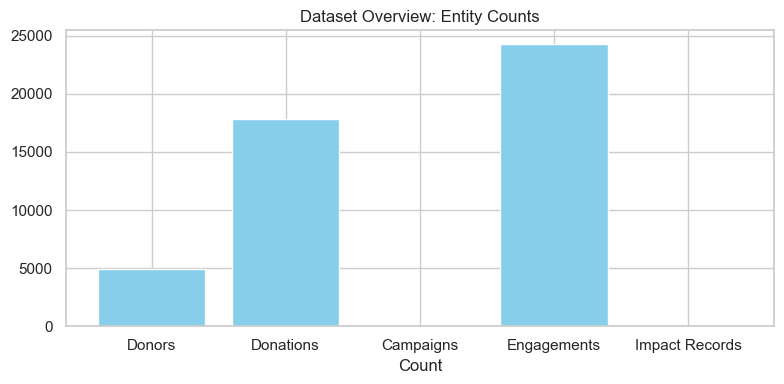

**Figure 1. Overview of Entities in the Dataset** This chart summarises the number of records available for each major data table used in the analysis. It helps contextualise the scale and depth of the insights that follow.

## 4. Using Data to Understand Engagement

Understanding engagement requires more than simply counting donations or responses. It involves examining how donors behave, how frequently they interact with the organisation, and how effective outreach and campaigns have been over time. This section explores engagement through three lenses: individual donor behaviour, engagement history, and campaign performance. Each area reveals opportunities to improve targeting, increase retention, and align fundraising efforts with impact delivery (Virtuous, 2024; FundsforNGOs, 2025).

#### 4.1 Donor Behaviour & Recency Analysis

Building lasting relationships with donors is essential for nonprofit success. However, many organisations find it difficult to understand how engaged their supporters really are. Without the right data or systems, important signals—like when someone stops donating or responding—can easily be missed (Virtuous, 2024).

In our dataset of 4800 plus donors, a large portion are at risk or lost. This means they have not donated or interacted with the organisation for some time. This reflects a common problem in the sector: it is often easier to focus on finding new donors than staying connected to the ones you already have (FundsforNGOs, n.d.). According to sector benchmarks, donor retention rates remain a critical challenge across the industry, with over 50% of first-time donors never giving again (Association of Fundraising Professionals, 2021).

Looking at how often people give, how much they donate, and how recently they were contacted can help organisations group their donors in smarter ways. For example, one-time givers can be included in re-engagement campaigns, while long-term supporters might be thanked with personalised updates or invitations.

Without these insights, engagement can feel too general or come too late. But when data is used well, it can help organisations stay connected, be more relevant, and build stronger trust with their communities.

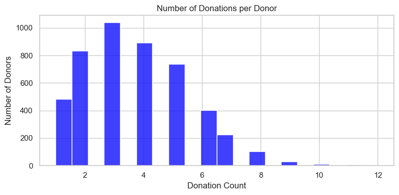

**Figure 2. Number of Donations per Donor** This chart illustrates how frequently individual donors contribute. Most donors have given between 2 and 4 times, indicating moderate retention. There remains a sizeable portion with only one donation, pointing to opportunities for first-time donor re-engagement.

##### 4.1.1 Donor Retention Snapshot

Retention is one of the most critical indicators of fundraising health, and tracking it by segment allows nonprofits to intervene early and prioritise long-term relationship-building over one-off transactions.

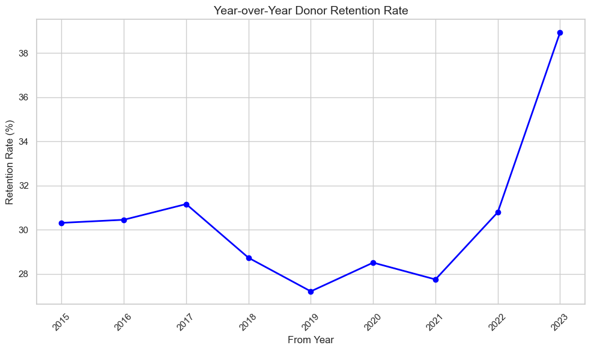

**Figure 3. Year-over-Year Donor Retention Rate** This line graph illustrates the percentage of donors retained from one year to the next over a ten-year period. While retention fluctuates around the sector benchmark of 30%, occasional dips highlight the importance of targeted re-engagement strategies and sustained communication with donor segments.

**Retention** is one of the most critical—and often overlooked—indicators of fundraising health in the nonprofit sector. High acquisition costs make it significantly more cost-effective to retain existing donors than to acquire new ones. Yet many organisations experience substantial year-over-year donor churn due to inconsistent engagement, lack of personalisation, and minimal follow-up. By tracking retention trends and applying targeted engagement strategies, nonprofits can improve donor lifetime value, deepen relationships, and increase the sustainability of their mission-driven efforts.

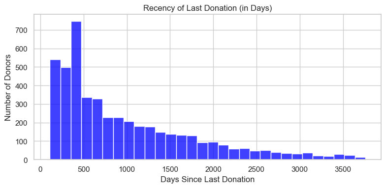

**Figure 4. Recency of Last Donation**  
This distribution shows how many days have passed since each donor’s last donation. Recency analysis assesses the overall health of donor relationships. The distribution above shows a wide range in recency, reinforcing the value of tracking and responding to supporter activity over time. It provides a foundation for recency-based segmentation or re-engagement targeting.

#### 4.2 Donor Engagement Patterns & Segmentation Logic

To better understand the patterns of donor engagement, we analysed recent donation behaviours and frequency of contact. However, surface-level metrics often fail to capture the complexity of donor commitment and potential. To address this, we implemented a modified RFM (Recency, Frequency, Monetary) segmentation model tailored for the nonprofit context.

Unlike traditional percentile-based RFM scoring, our approach uses rule-based segmentation reflecting real-world donor types. This allowed us to group supporters by behavioural traits—such as consistent loyalty, high-value giving, or lapsing engagement—rather than demographic assumptions or isolated transactions.

This logic forms the analytical backbone of the report, supporting all subsequent insights related to engagement, campaign targeting, and strategic recommendations. The full segmentation results and their implications are explored in detail in **Section 5: RFM Segmentation & Donor Profiling**.

|  | Segment | Count |
| --- | --- | --- |
| 0 | Loyal Donors | 1737 |
| 1 | Lapsed but Valuable | 789 |
| 2 | At Risk | 737 |
| 3 | Low Frequency | 476 |
| 4 | Misc Donors | 421 |
| 5 | Lost or Inactive | 357 |
| 6 | Champions | 207 |
| 7 | Never Donated | 122 |
| 8 | New Donors | 24 |
| 9 | High Value Potentials | 21 |

#### 4.3 Engagement History – Closing the Feedback Loop

Donor engagement is not a one-time event—it is an ongoing relationship built through consistent, timely, and relevant communication. Yet many nonprofit organisations fall into the trap of either over-communicating with all supporters or not reaching out at all. Without tracking engagement history, it becomes difficult to know who has been contacted, how often, and whether the communication was effective (Virtuous, 2024).

By reviewing engagement history—such as contact dates, channels used, and donor responses—organisations can create a clearer picture of what works and what does not. For example, supporters who consistently open newsletters or respond to event invites might benefit from more targeted appeals. Those who have not been contacted in a long time may need a re-introduction or a story that reconnects them to the mission.

Closing the loop on engagement means using data to listen as well as speak. It requires tracking not only what messages are sent but how supporters respond. The latest trends indicate that nonprofits who invest in multi-channel engagement strategies report higher donor satisfaction and retention (Salesforce.org, 2023). Doing so allows organisations to communicate more intentionally and build trust over time, increasing the chances that a donor remains involved for the long term (Nonprofits Source, n.d.).

To better understand who is responding to outreach efforts, we use donor segmentation (described in detail in Section 5) to analyse engagement outcomes across donor types.

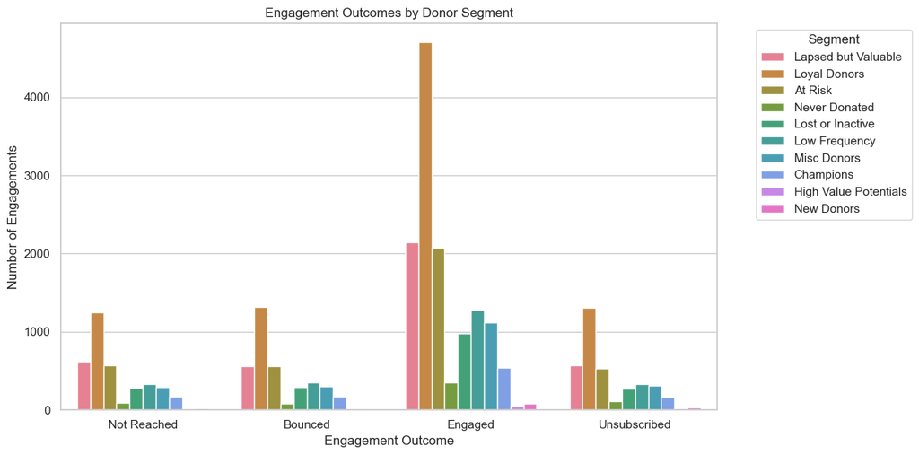

[figure not shown]

#### 4.4 Campaign Participation by Donor Segment

To better understand how different types of supporters contribute across fundraising campaigns, we can analyse donation data in combination with donor segmentation. This allows us to identify which donor segments are most active in each campaign. For instance, campaigns heavily supported by “Loyal Donors” or “Champions” may reflect strong relationships and targeted outreach, whereas campaigns with limited segment diversity may require broader engagement strategies.

By visualising total donations by segment and campaign in a heatmap, we highlight segment concentration patterns. This helps nonprofit teams assess whether they are reaching a balanced supporter base—or relying too heavily on a few segments—and whether high-potential segments are being underutilised.

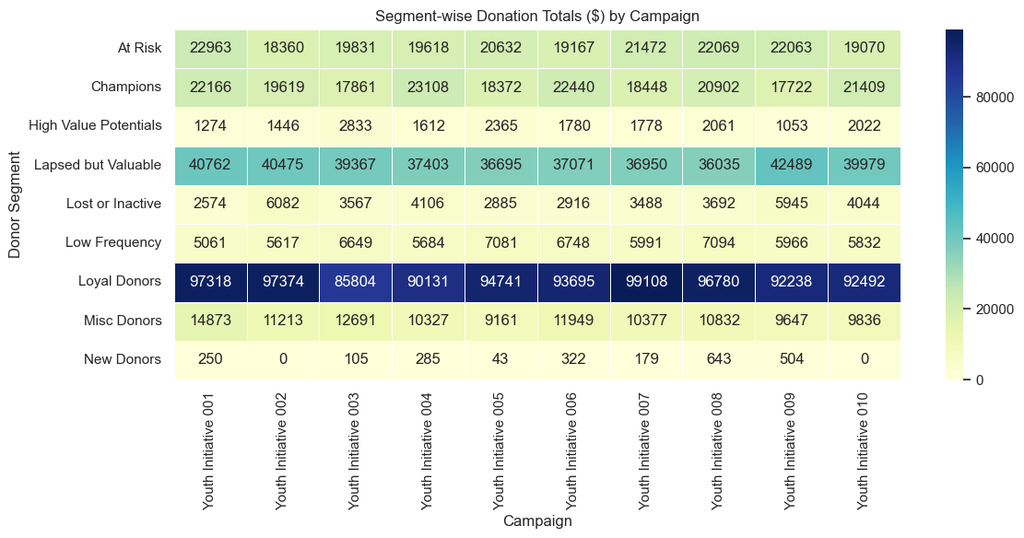

**Figure 7. Segment-wise Donation Totals by Campaign** This heatmap illustrates the total donation amounts contributed by each donor segment across different campaigns. Notably, Loyal Donors consistently contribute the highest totals, suggesting strong alignment and retention across initiatives. Other segments such as Lapsed but Valuable and Champions also show meaningful engagement. This segmentation-based view helps identify which supporter types are driving each campaign’s performance, enabling more targeted planning and messaging.

#### 4.5 Campaign Performance & Impact Alignment

Beyond fundraising targets, it is essential to assess whether campaigns deliver tangible outcomes that align with their purpose. Evaluating the impact of fundraising efforts is also essential to ensure that organisational resources are being used efficiently (Gallo, 2014).A high-performing campaign is not just one that meets its funding goal but also one that translates those funds into meaningful community impact. By evaluating the dollar value of impact delivered per dollar raised, we gain a clearer picture of operational efficiency and program effectiveness.

As shown in **Figure 8**, several campaigns are achieving over 80 cents of direct impact delivery per dollar raised. This suggests a strong value proposition for donors and stakeholders. Campaigns with lower efficiency may warrant further review to understand if administrative costs, outreach challenges, or delivery inefficiencies are affecting impact returns. This form of analysis supports more strategic allocation of resources and encourages a culture of outcome-driven planning.

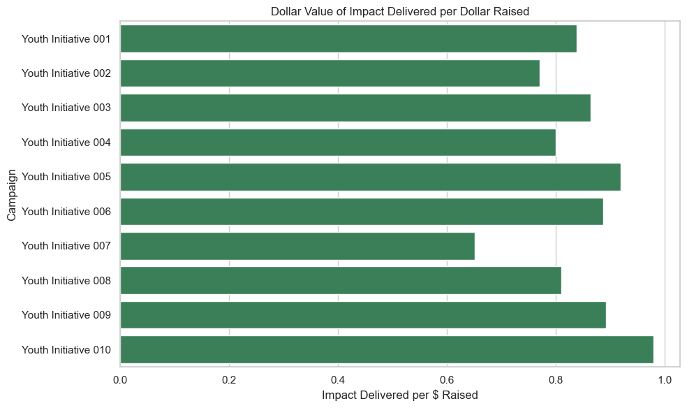

**Figure 8. Dollar Value of Impact per Dollar Raised** This chart compares each campaign’s effectiveness in converting raised funds into direct program delivery, based on the dollar value of reported outcomes. Campaigns closer to a 1:1 ratio are operating more efficiently, delivering high-impact results relative to funds raised. This insight helps prioritise scalable and cost-effective campaign models.

## 5. RFM Segmentation & Donor Profiling

Understanding donor behaviour is fundamental to building long-term relationships and sustaining fundraising success. To move beyond surface-level metrics, we implemented a customised version of the RFM (Recency, Frequency, Monetary) model to segment donors into meaningful behavioural groups. This approach enables nonprofits to tailor their engagement and fundraising strategies based on actual giving patterns and levels of involvement.

#### 5.1 Segment Definitions & Rules

Rather than relying solely on quantile scoring, we applied rule-based classification grounded in sector best practices. Each donor was assigned to one segment based on a combination of donation timing (Recency), number of gifts (Frequency), and contribution value (Monetary). The segmentation logic is outlined below:

**New Donors:** Made their first donation in the past 12 months, with total giving under $500. Strategy: Nurture with welcome series and onboarding journeys.

**Loyal Donors:** Donated in each of the last three calendar years. Strategy: Prioritise relationship-building, personalised updates, and stewardship.

**High Value Potentials:** Donated over $500 in a single gift within the past three years, with moderate frequency. Strategy: Flag for major gift cultivation and one-on-one outreach.

**Champions:** Donated frequently (4+ times), recently (within the last year), and generously (≥$750 total). Strategy: Recognise, retain, and invite into deeper involvement (e.g. ambassador roles, feedback forums).

**At Risk:** Last donation was between 12 to 36 months ago, with a frequency of 2 or more but low recent activity. Strategy: Reconnect with value-based messaging and retention offers.

**Lapsed but Valuable:** Last donation was over 3 years ago, but historical value was substantial (≥$250 total). Strategy: Launch personalised reactivation campaigns.

**Lost or Inactive:** Last donation was over 3 years ago, typically with just one low-value contribution. Strategy: Suppress from high-cost communications; offer low-effort re-engagement opportunities.

**Low Frequency:** Fewer than three donations, with total giving below $250. Strategy: Target with light-touch engagement and surveys to understand barriers.

**Misc Donors:** Active donors who did not meet the criteria of any defined group. Strategy: Monitor for behavioural patterns that may shift them into clearer segments.

**Never Donated:** No donations recorded in the dataset. Strategy: Evaluate for acquisition pipeline suitability or other forms of involvement.

This segmentation allows for more nuanced targeting across the donor lifecycle—enabling organisations to invest in the right relationships, at the right time, with the right message.

#### 5.2 Donor Segment Distribution

Once donor segments were established using a rule-based RFM framework, we analysed the composition of the supporter base to identify strategic strengths and vulnerabilities.

The chart below shows the number of donors in each segment. Notably, **Loyal Donors** constitute the largest segment by a significant margin—indicating a strong foundation of committed supporters. This is a positive signal for long-term sustainability and relationship-based fundraising.

However, other segments like *Lapsed but Valuable*, *At Risk*, and *Low Frequency* donors represent sizable proportions of the donor base. These groups, while still active or recently disengaged, signal substantial opportunity for **reactivation campaigns**, **personalised outreach**, and **retention efforts**.

Conversely, segments such as *New Donors*, *Champions*, and *High Value Potentials* are underrepresented. This suggests that while initial acquisition may be functioning, the pipeline for major gift cultivation and long-term value development may be limited.

Overall, the distribution illustrates that acquisition is not the core challenge—but **consistency and lifecycle management** are. Future strategy should focus on retention, growth of high-value pathways, and unlocking more from mid-tier donor segments.

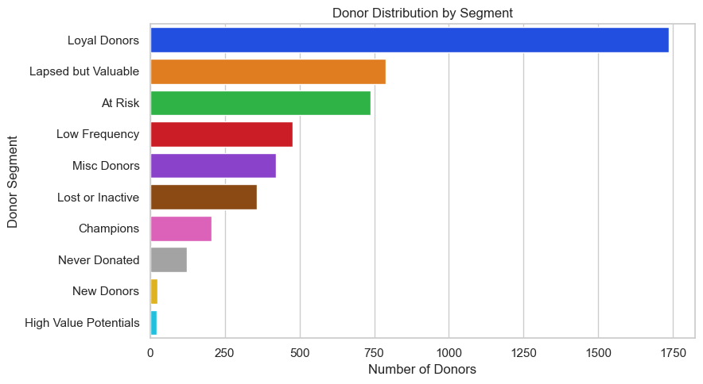

**Figure 9. Donor Distribution by Segment**  
*This chart displays the number of supporters in each segment. While Loyal Donors dominate the distribution, other segments with untapped or at-risk value represent critical areas for strategic focus.*

#### 5.3 Segment-Level Performance Analysis

Understanding how different donor segments behave beyond classification helps translate analysis into action. By examining donation volume, value, and engagement patterns across segments, we can prioritise outreach, tailor campaign messaging, and allocate resources more effectively.

As nonprofits face increasing pressure to maximise both impact and efficiency, segmenting the donor base provides a critical decision-making tool. Campaigns that rely on a generalised message miss the opportunity to speak to the needs, motivations, and capacities of distinct groups. For example, **‘Champions’** may respond better to personal updates or recognition, while **‘At Risk’** donors may require reactivation nudges that acknowledge past support.

The analysis below aggregates key performance indicators—such as average gift, and engagement frequency—by donor segment. This provides a practical lens into which segments are contributing the most financially, which have strong potential, and which require attention. These insights directly inform smarter campaign targeting, messaging design, and fundraising investment.

This segmentation strategy is aligned with best practices recommended by the IIBA’s Business Data Analytics Guide, which emphasizes targeted analysis and actionable insight (International Institute of Business Analysis, 2019).

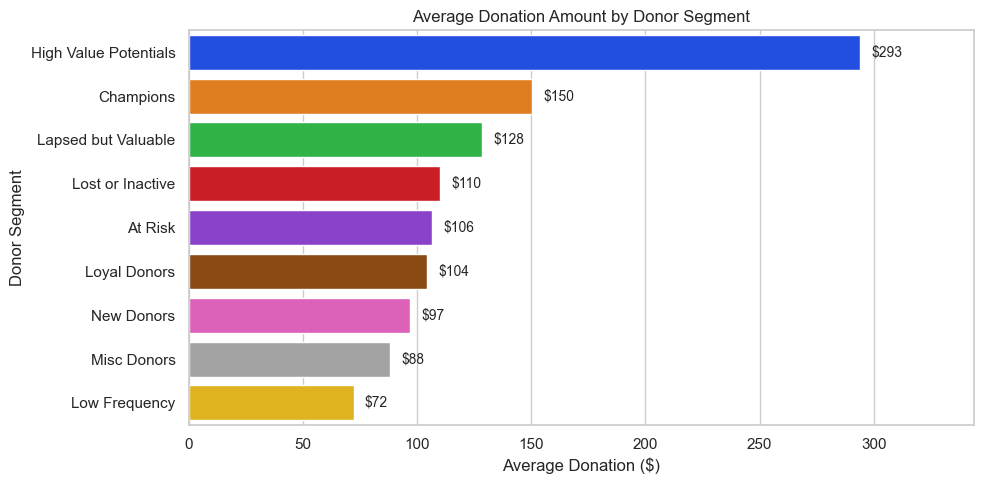

**Figure 10. Average Donation Amount by Segment** This chart illustrates the average donation amount for each defined donor segment. High Value Potentials and Champions clearly lead in contribution size, reinforcing their strategic importance for personalized engagement and major giving cultivation. Conversely, Low Frequency and Misc Donors contribute smaller average amounts, indicating a need for targeted uplift strategies. Segment-specific approaches can help maximize giving potential and overall fundraising efficiency.

**Interpretation of Engagement Frequency**

Notably, segments like Champions and High Value Potentials, who demonstrate strong donation behaviour, are not being engaged at higher rates than segments like Low Frequency or Misc Donors. This uniformity suggests that current communication efforts are not fully aligned with donor value or potential.

This finding underscores the need for a tiered engagement approach—one that increases communication frequency and personalisation for high-value segments while testing re-engagement strategies for those at risk or lapsed.

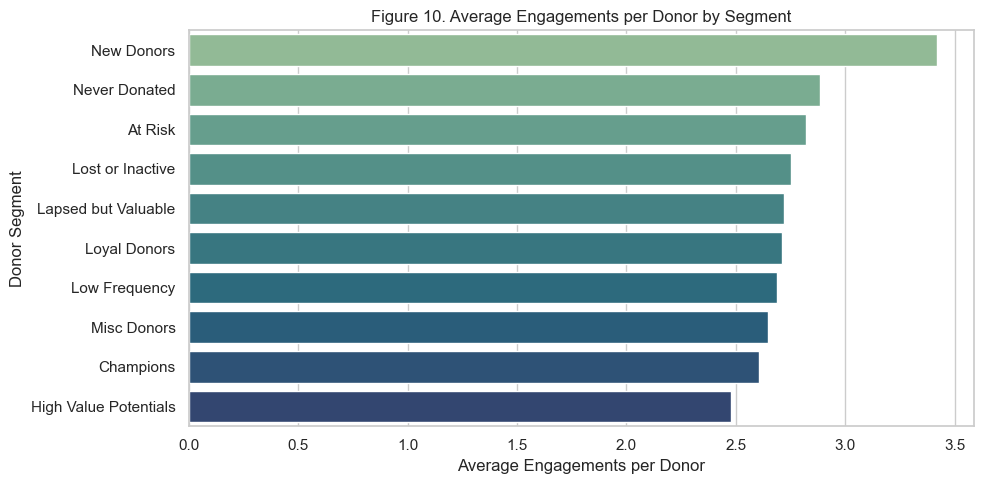

**Figure 11. Average Engagements per Donor by Segment**  
Engagement levels are evenly distributed across segments, revealing limited differentiation in outreach strategy regardless of donor value or behaviour.

#### 5.4 Missed Opportunities

Conversely, segments such as At Risk and Lost or Inactive contain substantial numbers of past donors who have lapsed in activity. Tailored re-engagement campaigns—using data to personalise timing, messaging, and channels—can effectively win back lapsed donors (Charity Digital, 2022).

This underlines a key insight: the organisation's data is not yet being leveraged to its full potential. Campaign and engagement strategies remain largely undifferentiated, missing opportunities to build stronger donor journeys aligned with segment-specific behaviour and value.

Better utilisation of behavioural segmentation can guide focused investment in retention and upgrade strategies—ultimately driving higher fundraising ROI and deeper supporter relationships.

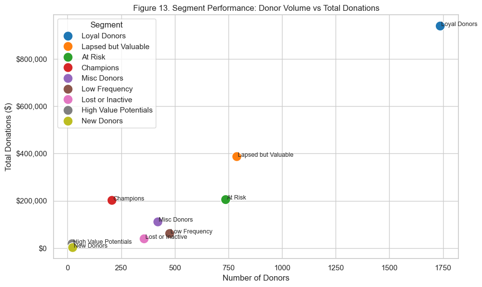

This scatterplot compares the number of donors in each behavioural segment with the total amount they have contributed. It highlights segments such as Loyal Donors, who contribute the highest total value, and Champions and High Value Potentials, who offer strong financial potential despite smaller populations. By synthesising volume and value, this visual helps identify which donor groups should be prioritised for retention, stewardship, or strategic re-engagement.

## 6. Recommendations

To improve donor retention, engagement, and overall campaign effectiveness, nonprofits should adopt a more strategic and data-informed approach to supporter management. Based on the analysis in this report, the following recommendations are offered:

### Segment and Personalise Donor Communication

Use RFM segmentation to develop targeted communication strategies tailored to each donor group. For example:

- **Loyal Donors**: Prioritise stewardship, updates on impact, and early access to new campaigns.
- **High-Value Potentials**: Use tailored messaging and high-touch communication to convert into top-tier donors.
- **At-Risk and Lapsed Donors**: Launch re-engagement campaigns with personalised asks and storytelling.

### Align Campaign Messaging with Impact Metrics

Bridge the gap between fundraising and program delivery by explicitly linking dollars raised to outcomes achieved. This transparency fosters trust and helps donors understand the tangible results of their support.

### Optimise Channel Strategy Based on Engagement Data

Leverage engagement history to understand which communication channels yield the highest response rates by segment. For example:

- **Email** may work best for digitally active Loyal Donors.
- **Phone or in-person** may be more effective for lapsed or older donor segments.

### Implement Feedback Loops in Engagement Strategy

Create automated or staff-led feedback mechanisms to track donor responses, preferences, and behavioural shifts. Use this data to adjust strategies in near real-time rather than waiting for campaign outcomes to drive decisions.

### Monitor Segment-Level KPIs Over Time

Develop dashboards or monthly reports that track KPIs (retention rate, engagement frequency, average gift size) by segment. This enables stakeholders to evaluate what's working and adjust quickly.

### Build Internal Capacity for Data Use

Invest in staff training or partnerships that improve internal data literacy and build a culture of evidence-based decision-making. Even small nonprofits can benefit from lightweight tools and templates for segmentation, performance tracking, and insight generation.

## 7. Conclusion

This project set out to demonstrate how nonprofits can use data to better understand and strengthen donor engagement. Through a combination of donor segmentation, campaign analysis, and engagement tracking, we explored both the opportunities and gaps in current fundraising strategies.

Our modified RFM segmentation revealed that while valuable donor groups exist—such as *Champions*, *Loyal Donors*, and *High Value Potentials*—they are not yet receiving targeted engagement aligned with their behaviours and giving potential. Similarly, *At Risk* and *Lapsed but Valuable* donors represent substantial re-engagement opportunities that remain underexplored.

Engagement analysis further highlighted a consistent, uniform outreach pattern across all donor groups, with no evidence of prioritisation based on donor value. Campaign-level insights also showed performance variance with limited targeting by segment, reinforcing the need for more strategic design and execution.

Despite these challenges, the project demonstrates that even with modest tools—such as Python, CSV files, and basic visualisation libraries—nonprofits can uncover meaningful insights that lead to smarter, more tailored engagement strategies.

Looking ahead, the integration of donor data into campaign design, engagement planning, and impact reporting can create a feedback loop that enhances both fundraising effectiveness and mission delivery. A culture of evidence-based decision-making can ensure that every donor interaction is more timely, relevant, and mission-aligned.

## 8. References

- Andresen, K., & Nowicki, C. (2020). Nonprofit data and strategy integration. *Journal of Nonprofit Management*, *24*(2), 45–62.
- Association of Fundraising Professionals. (2021). *Fundraising effectiveness project: 2021 annual report*. https://afpglobal.org/fep
- Business Data Analytics Guide v1.0. (2019). International Institute of Business Analysis (IIBA).
- Charity Digital. (2022). *How to re-engage lapsed donors*. https://charitydigital.org.uk/topics/how-to-reengage-lapsed-donors-9835
- Funraise. (2024). *The state of nonprofit engagement*. https://www.funraise.org
- Gallo, A. (2014). A refresher on marketing ROI. *Harvard Business Review*. https://hbr.org/2014/07/a-refresher-on-marketing-roi
- McKinsey & Company. (2021). *The data-driven nonprofit: Insights and pathways*. https://www.mckinsey.com/industries/social-sector/our-insights/the-data-driven-nonprofit
- Nonprofits Source. (n.d.). *2024 digital giving and donor retention trends*. https://nonprofitssource.com/online-giving-statistics
- Salesforce.org. (2023). *Nonprofit trends report: 5th edition*. https://www.salesforce.org/resources/research/nonprofit-trends-report
- Virtuous. (2024). *State of nonprofit donor experience*. https://www.virtuous.org/resources
- Analytics for Good Institute. (2020). *Data science for social impact: Challenges and strategies in the nonprofit sector*. https://analyticsforgood.org/reports